# Introdução à Ciência de Dados

## Estatísticas Descritivas

```r
# calcula estatísticas descritivas

economics %>%
  summarise(
    media = mean(unemploy, na.rm = TRUE),
    mediana = median(unemploy, na.rm = TRUE),
    desvio_padrao = sd(unemploy, na.rm = TRUE),
    assimetria = fBasics::skewness(unemploy, na.rm = TRUE),
    curtose = fBasics::kurtosis(unemploy, na.rm = TRUE)
  )
```

```
# A tibble: 1 × 5
  media mediana desvio_padrao assimetria curtose
  <dbl>   <dbl>         <dbl>      <dbl>   <dbl>
1 7771.    7494         2642.      0.697   0.795
```

## Uma Análise Plausível

**Análise do Histograma**

O histograma apresenta distribuição unimodal com assimetria positiva entre fraca e moderada (coeficiente de assimetria 0,697), indicando que houve períodos ocasionais de alto desemprego. A concentração principal ocorreu entre 5 e 10 milhões de desempregados aproximadamente

A distribuição unimodal com alguma assimetria positiva indica que a maioria das observações concentra-se em níveis de desemprego moderados, enquanto episódios de alto desemprego ocorreram com menor frequências, assim, possivelmente a assimetria observada captura recessivos econômicos ou eventos excepcionais ocorridos no período analisado.

## Densidade Empírica (ou Kernel da Densidade)

**O que é um gráfico de densidade empírica?**

- Um gráfico da densidade empírica dos dados é uma representação visual que estima a função densidade de probabilidade de uma variável numérica contínua.
- Diferente do histograma, que agrupa os dados em intervalos mostra a frequência absoluta de cada intervalo, o gráfico de densidade suaviza os dados para formar uma curva contínua.
- Este tipo de gráfico é gerado através de um processo conhecido como  
  **estimativa do kernel da densidade**.
- A ideia básica por trás da estimação do kernel de uma densidade é suavizar os pontos de dados individuais em toda a região do espaço de dados, de forma a obter uma estimativa contínua para a função de probabilidade.
- Isso é feito utilizando uma função conhecida como “**kernel**”, que distribui o peso dos pontos de dados ao longo de um intervalo de valores, com o maior peso geralmente no centro e diminuindo conforme se afasta do ponto central.

Um dos kernels mais comuns é o kernel gaussiano:

$$K(x) = \frac{1}{\sqrt{2 \pi}} \exp \left(-\frac{x^2}{2}\right)$$

- A estimativa da densidade $f(x)$ em um ponto $x$ é dada por:

$$f(x) = \frac{1}{nh}\sum_{i=1}^{n} K\left(\frac{x - x_i}{h}\right)$$

sendo:

- $n$ o número de pontos de dados,
- $x_i$ são os dados,
- $K$ é a função do kernel,
- $h$ é a largura da banda ou intervalo (*binwidth*), um parâmetro crítico que controla o grau de suavização da estimativa da densidade.

## Densidade Empírica

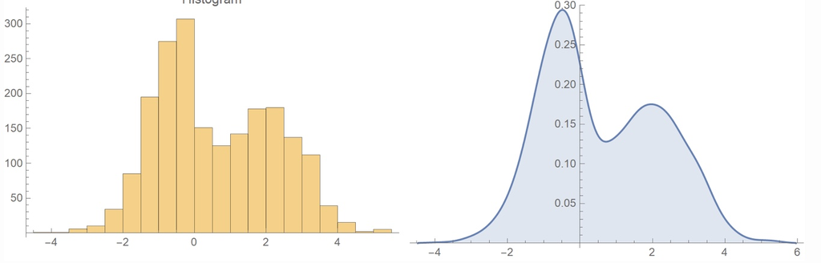

**Interpretação**

- A interpretação do gráfico da densidade empírica segue a mesma lógica da interpretação de um histograma, implicando nas mesmas conclusões.

## Densidade Exploratória

```r
# salva o gráfico em um objeto
densidade_exploratoria <-
  # ggplot() cria um sistema de coordenadas vazio
  ggplot(economics, aes(x = unemploy/1000)) +
  # adiciona um gráfico de densidade
  geom_density()

# exibe o gráfico
densidade_exploratoria
```

## Densidade Exploratória

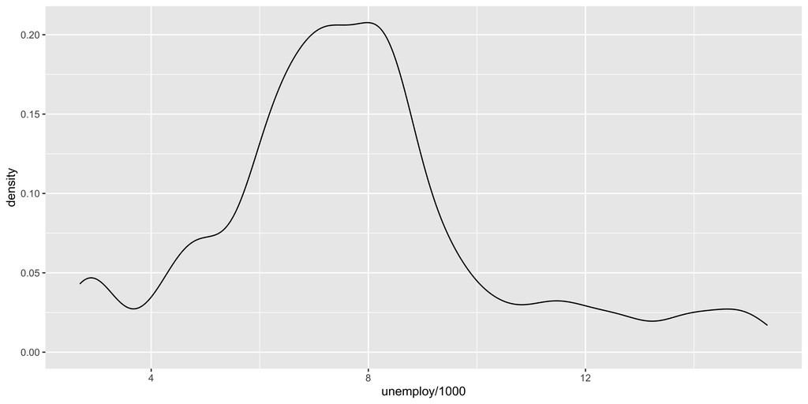

## Densidade para Publicação

```r
# salva o gráfico em um objeto
densidade_publicacao <-
  # ggplot() cria um sistema de coordenadas vazio
  ggplot(economics, aes(x = unemploy/1000)) +
  # adiciona um gráfico de densidade
  # size define a espessura da linha
  geom_density(size = 1) +
  # adiciona título, subtítulo, rótulos dos eixos e fonte
  labs(
    title = "Distribuição do Desemprego nos EUA",
    subtitle = "Período: 1967-2015",
    x = "Total de Desempregados (milhões)",
    y = "Densidade",
    caption = "Fonte: Bureau of Labor Statistics"
  )  +
  # define o tema do gráfico
  theme_minimal()

# exibe o gráfico
densidade_publicacao
```

## Densidade para Publicação

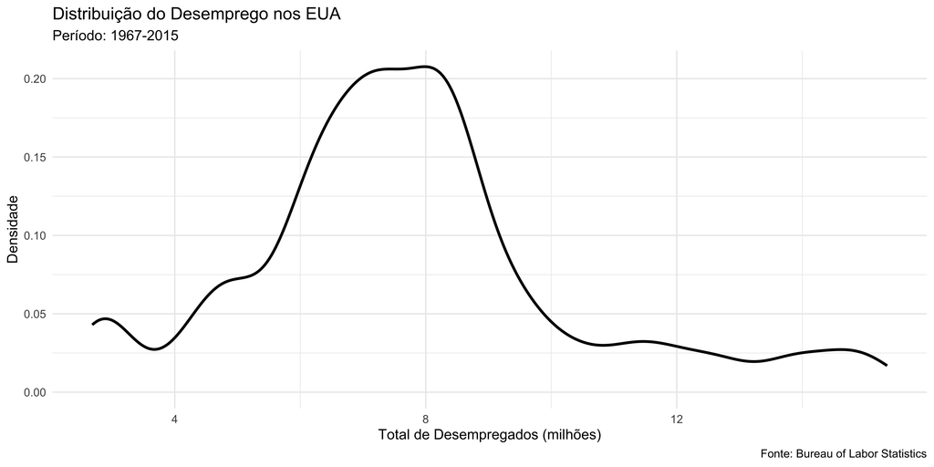

## Histograma com densidade empírica sobreposta

```r
# salva o gráfico em um objeto
histograma_densidade <-
  # ggplot() cria um sistema de coordenadas vazio
  ggplot(economics, aes(x = unemploy/1000))  +
  # adiciona um histograma
  geom_histogram(
    aes(y = after_stat(density)), # normaliza o histograma
    bins = 10,
    fill = "#E6F2FF",     # azul muito claro para as barras
    color = "#2E5984"     # azul escuro para borda das barras
  ) +
  # adiciona uma densidade empírica
  geom_density(
    alpha = .3,       # transparência
    fill = "#1B3A57"  # azul navy para a densidade
  ) +
  # adiciona título, subtítulo, rótulos dos eixos e fonte
  labs(
    title = "Distribuição do Desemprego nos EUA",
    subtitle = "Período: 1967-2015",
    x = "Total de Desempregados (milhões)",
    y = "Densidade",
    caption = "Fonte: Bureau of Labor Statistics"
  ) +
  # define o tema do gráfico
  theme_minimal()

histograma_densidade
```

## Histograma com densidade empírica sobreposta

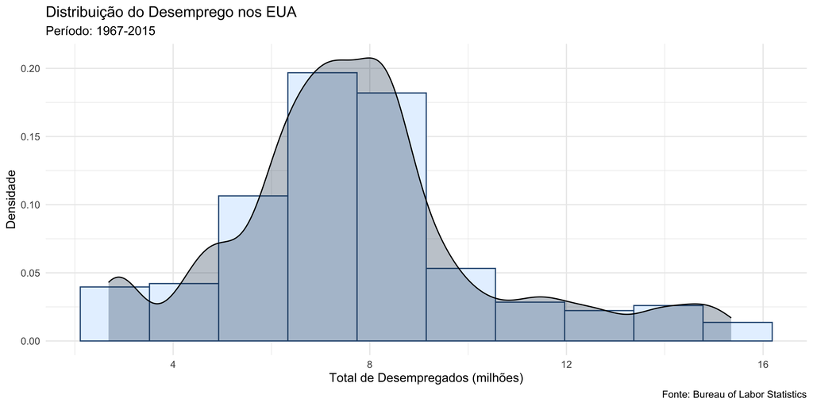

## Boxplot

**O que é um boxplot?**

- Um gráfico boxplot (gráfico de caixa) é um gráfico que descreve várias características essenciais de uma distribuição de dados através de um resumo de cinco números (estatísticas):
- o valor mínimo,
- o primeiro quartil (Q1),
- a mediana (segundo quartil, Q2),
- o terceiro quartil (Q3)
- o valor máximo.
- Este gráfico fornece uma representação compacta da distribuição de um conjunto de dados, destacando a mediana, a variabilidade, a assimetria e os valores extremos (outliers).

## Boxplot

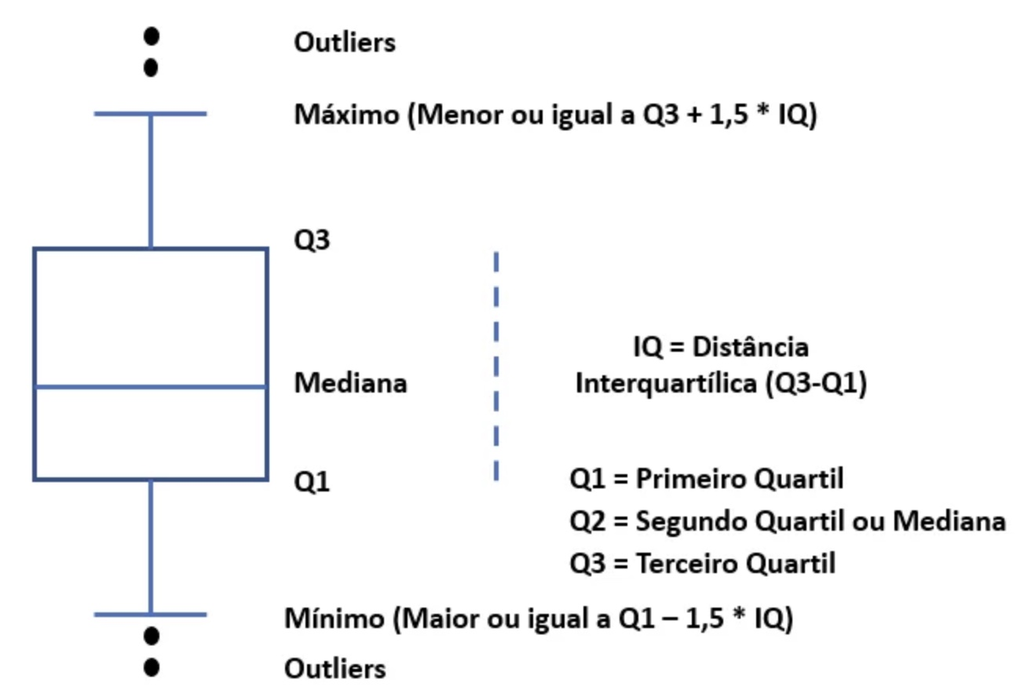

## Boxplot: Interpretação

**Componentes e Interpretação**

- **Mediana**: Linha central da caixa (Q2)
- **Quartis**: Extremidades da caixa representam Q1 e Q3, delimitando o IQR
- **Bigodes**: Estendem-se até os valores mais extremos dos dados **que não são outliers**
- **Outliers**: Pontos isolados além dos bigodes

**Critério para definição de outliers:**

- **Limite inferior**: $Q1 - 1.5 \times IQR$
- **Limite superior**: $Q3 + 1.5 \times IQR$
- Qualquer observação fora desses limites é considerada outlier

**Como os bigodes são definidos:**

- **Bigode inferior**: vai até o **menor valor** dos dados que seja $\geq Q1 - 1.5 \times IQR$
- **Bigode superior**: vai até o **maior valor** dos dados que seja $\leq Q3 + 1.5 \times IQR$
- Se não há outliers, os bigodes vão até o mínimo e máximo reais dos dados

**Interpretação visual:**

- **Assimetria**: Posição da mediana na caixa e comprimento relativo dos bigodes
- **Variabilidade**: Altura da caixa (IQR contém 50% dos dados centrais)

## Boxplot: Interpretação

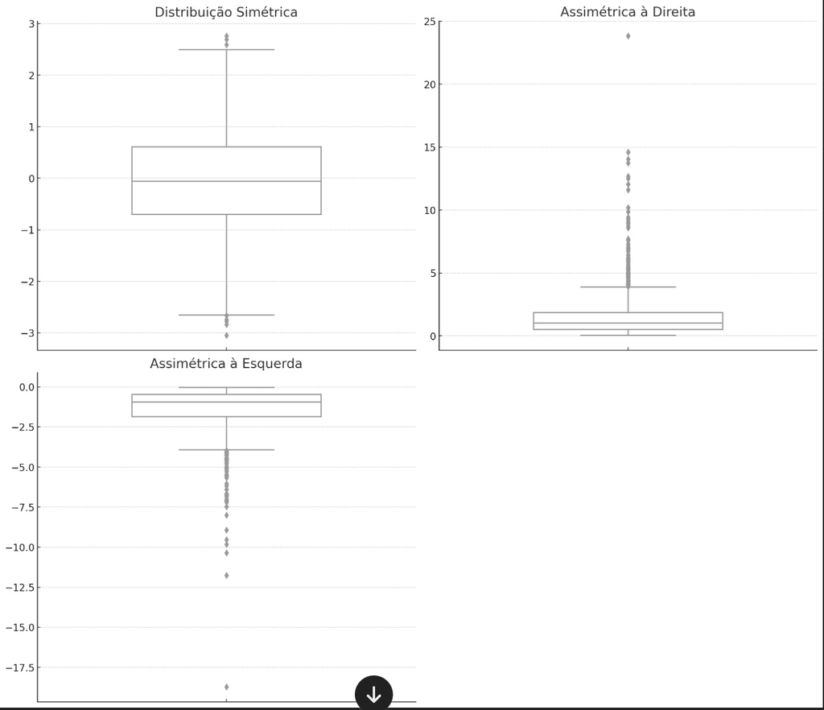

## Boxplot Exploratório

```r
# salva o gráfico em um objeto
boxplot_exploratorio <-
  # ggplot() cria um sistema de coordenadas vazio
  ggplot(economics, aes(x = unemploy/1000)) +
  # adiciona um boxplot
  geom_boxplot()

# exibe o gráfico
boxplot_exploratorio
```

## Boxplot Exploratório

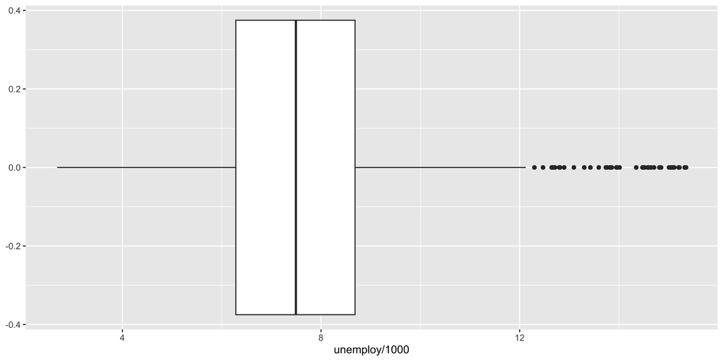

## Boxplot Exploratório

```r
# salva o gráfico em um objeto
boxplot_exploratorio_flip <-
  # ggplot() cria um sistema de coordenadas vazio
  ggplot(economics, aes(x = unemploy/1000)) +
  # adiciona um boxplot
  geom_boxplot() +
  # inverte os eixos
  coord_flip()

# exibe o gráfico
boxplot_exploratorio_flip
```

## Boxplot Exploratório

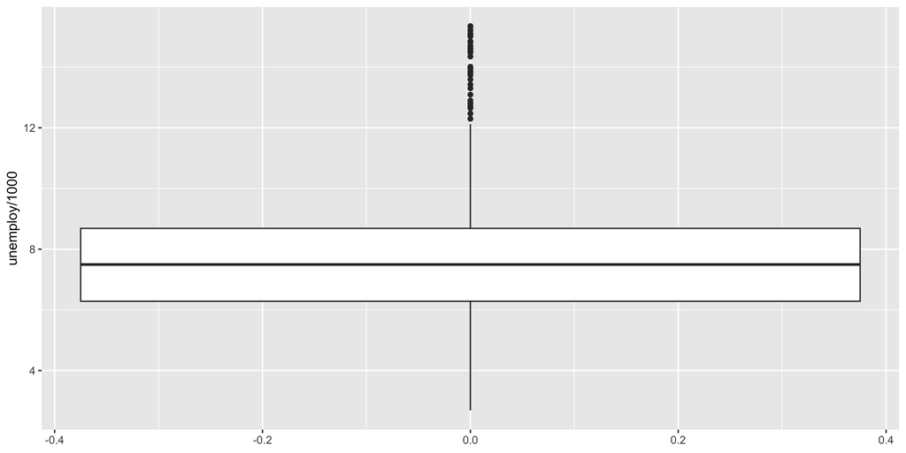

## Boxplot para Publicação

```r
# salva o gráfico em um objeto
boxplot_publicacao <-
  # ggplot() cria um sistema de coordenadas vazio
  ggplot(economics, aes(x = unemploy/1000)) +
  # adiciona um boxplot
  geom_boxplot() +
  # inverte os eixos
  coord_flip() +
  # adiciona zero no eixo X
  scale_x_continuous(limits = c(0, NA), expand = expansion(mult = c(0, 0.05))) +
  # adiciona título, subtítulo, rótulos dos eixos e fonte
  labs(
    title = "Distribuição do Desemprego nos EUA",
    subtitle = "Período: 1967-2015",
    x = "Total de Desempregados (milhões)",
    y = NULL, # remove o rótulo do eixo Y
    caption = "Fonte: Bureau of Labor Statistics"
  ) +
  # define o tema do gráfico
  theme_minimal() +
  # remove os rótulos do eixo X e as marcas do eixo X
  theme(
    axis.text.x = element_blank(),    # remove os rótulos do eixo X
    axis.ticks.x = element_blank()    # remove as marcas do eixo X
  )

# exibe o gráfico
boxplot_publicacao
```

## Boxplot para Publicação

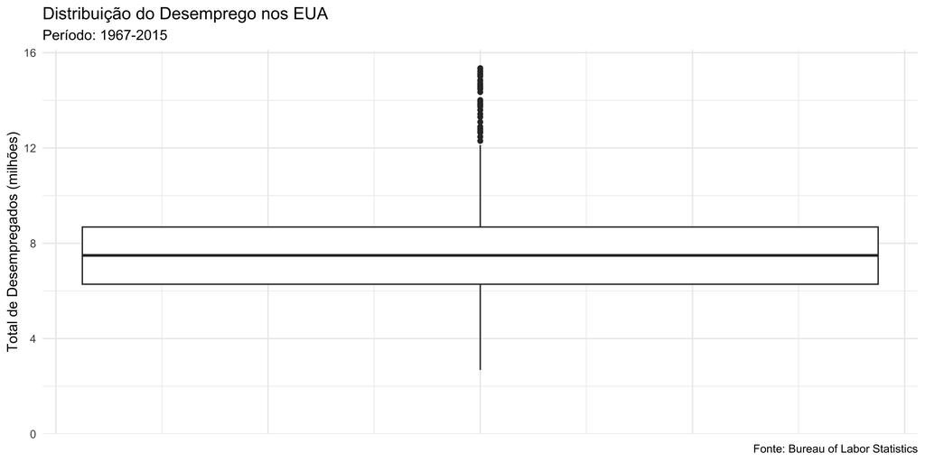

## Boxplot Comparativo

**Comparação de Grupos**

- Boxplots são úteis para **comparar a distribuição** de uma variável numérica entre diferentes grupos, sendo o grupo uma variável categórica.
- Esse gráfico permite identificar diferenças na tendência central, variabilidade, simetria/assimetria e presença de outliers entre os grupos, valores possíveis de uma variável categórica.

## Dados do Exemplo

**Descrição Geral**

Os data frame `diamonds` contém informações sobre 53.940 diamantes (linhas) e 10 variáveis (colunas), ela está contida no pacote ggplot2.

**Algumas Variáveis**

- **price** → Preço do diamante em dólares
- **carat** → Peso do diamante em quilates (1 quilate = 0.2 gramas)
- **cut** → Qualidade do corte (Fair, Good, Very Good, Premium, Ideal)
- **color** → Cor do diamante, escala de D (melhor) a J (pior)
- **clarity** → Medida da clareza do diamante, de I1 (pior), SI2, SI1, VS2, VS1, VVS2, VVS1 a IF (melhor)

## Boxplot Comparativo Exploratório

```r
# salva o gráfico em um objeto
boxplot_comparativo_exploratorio <-
  # ggplot() cria um sistema de coordenadas vazio
  ggplot(diamonds, aes(x = cut, y = price)) +
  # adiciona um boxplot
  geom_boxplot()

# exibe o gráfico
boxplot_comparativo_exploratorio
```

## Boxplot Comparativo Exploratório

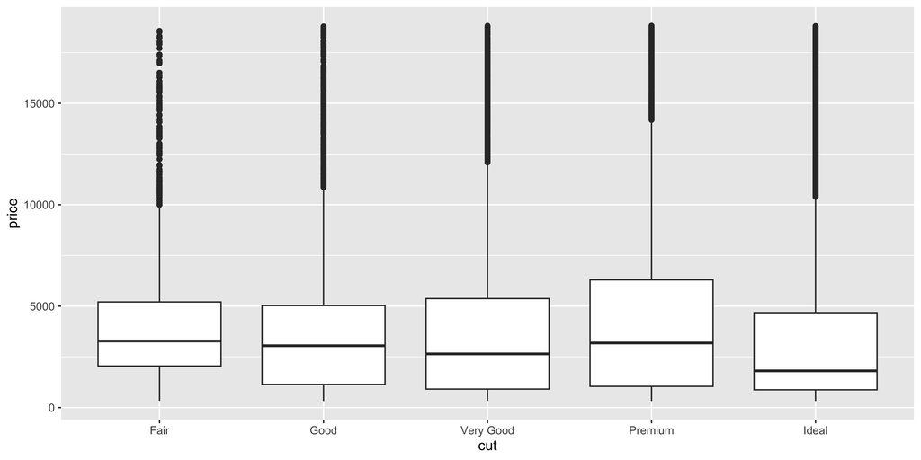

## Análise do Boxplot Exploratório

**Análise na Escala Original**

- A variável `price` apresenta uma distribuição fortemente assimétrica positiva (assimétria à direita), para todos os níveis de qualidade do corte (`cut`), com presença de muitos outliers.
- Tipicamente, a distribuição de preços de bens e serviços em geral tende a ser assimétrica à direita, com a maioria dos preços concentrados em torno de valores mais baixos, enquanto alguns poucos preços são muito altos, o que é o caso dos diamantes.
- Esta forte assimetria à direita torna difícil a visualização e interpretação dos dados para comparar os preços dos diamantes por qualidade do corte (`cut`), pois a presença de outliers distorce a análise, dificultando a identificação de padrões e tendências.
- Esse é um caso típico para aplicação de uma transformação logarítmica, que pode ajudar a reduzir a assimetria e melhorar a visualização e interpretação dos dados.

## Boxplot Comparativo - Transformação Logarítmica

```r
# salva o gráfico em um objeto
boxplot_comparativo_exploratorio <-
  # ggplot() cria um sistema de coordenadas vazio
  ggplot(diamonds, aes(x = cut, y = price)) +
  # adiciona um boxplot
  geom_boxplot() +
  # aplica a escala logarítmica no eixo Y
  scale_y_log10()

# exibe o gráfico
boxplot_comparativo_exploratorio
```

## Boxplot Comparativo - Transformação Logarítmica

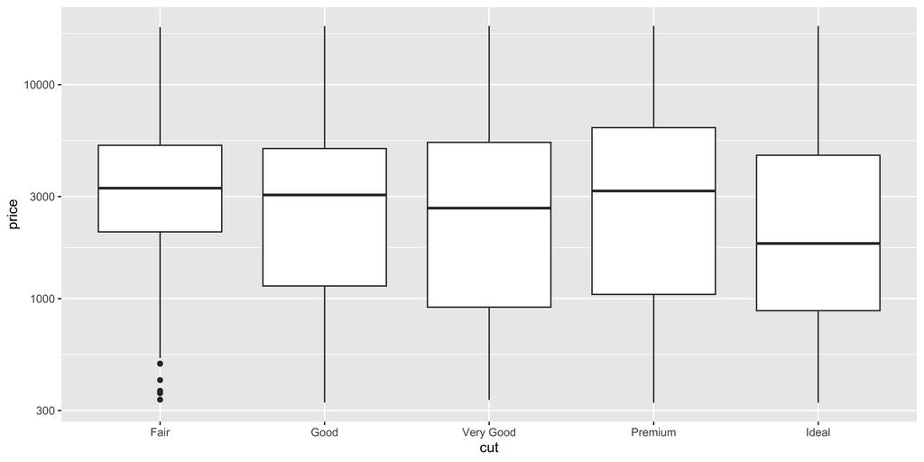

## Transformação Logarítmica

**Efeitos da Transformação Logarítmica**

- Útil para dados com distribuição assimétrica (ex.: a distribuição de preços), onde valores extremos distorcem a análise.
- **Reduz a influência de outliers** e aproxima a distribuição da normalidade, facilitando visualização e interpretação.
- Em boxplots, destaca diferenças na **mediana** e **variabilidade** entre grupos, minimizando o impacto de outliers.
- A escala logarítmica (eixo Y) melhora a comparação visual entre distribuições.

**Exemplo Numérico (base 10)**

- Valores originais: `[1, 10, 100, 1000]` → Transformados: `[0, 1, 2, 3]`.

**Interpretação:**

- A diferença entre **100 e 1000** (900 unidades) é reduzida para **1 unidade** (`3 – 2`).
- A diferença entre **1 e 10** (9 unidades) vira **1 unidade** (`1 – 0`).

**Conclusão:**

A transformação “comprime” a escala dos valores maiores, reduzindo a assimetria.

## Análise

**Análise dos Dados na Escala Logarítmica**

- **Simetria**: A transformação logarítmica tornou as distribuições mais simétricas e comparáveis, reduzindo o efeito de valores extremos.
- **Medianas**: Surpreendentemente, os preços medianos são similares entre as qualidades de corte, com diamantes `Ideal` apresentando preço mediano ligeiramente inferior.
- **Variabilidade**: A dispersão dos preços é aproximadamente homogênea entre os grupos, exceto para `Fair` que apresenta:
  - Menor variabilidade geral
  - Outliers inferiores indicando diamantes atipicamente baratos
- **Interpretação Cuidadosa**: Este padrão contra-intuitivo sugere que:
  - Outros fatores (quilates, clareza, cor) podem estar confundindo a relação corte-preço
  - Diamantes com corte superior podem ter características compensatórias (menor tamanho?)
  - É essencial realizar uma análise multivariada antes de conclusões definitivas
- **Lição Estatística**: Este exemplo ilustra a importância de não basear decisões em análises univariadas quando múltiplas variáveis interagem.

## Boxplot Comparativo para Publicação

```r
# salva o gráfico em um objeto
boxplot_comparativo_publicacao <-
  # ggplot() cria um sistema de coordenadas vazio
  ggplot(diamonds, aes(x = cut, y = price)) +
  # adiciona um boxplot
  geom_boxplot() +
  # aplica a escala logarítmica no eixo Y
  scale_y_log10() +
  # adiciona título, subtítulo, rótulos dos eixos e fonte
  labs(
    title = "Distribuição do Preço dos Diamantes por Qualidade do Corte",
    subtitle = "Data frame diamonds do pacote ggplot2",
    x = "Qualidade do Corte",
    y = "Preço (log10) em dólares",
    caption = "Fonte: Pacote ggplot2 da linguagem R"
  ) +
  # define o tema do gráfico
  theme_minimal()

# exibe o gráfico
boxplot_comparativo_publicacao
```

## Boxplot Comparativo para Publicação

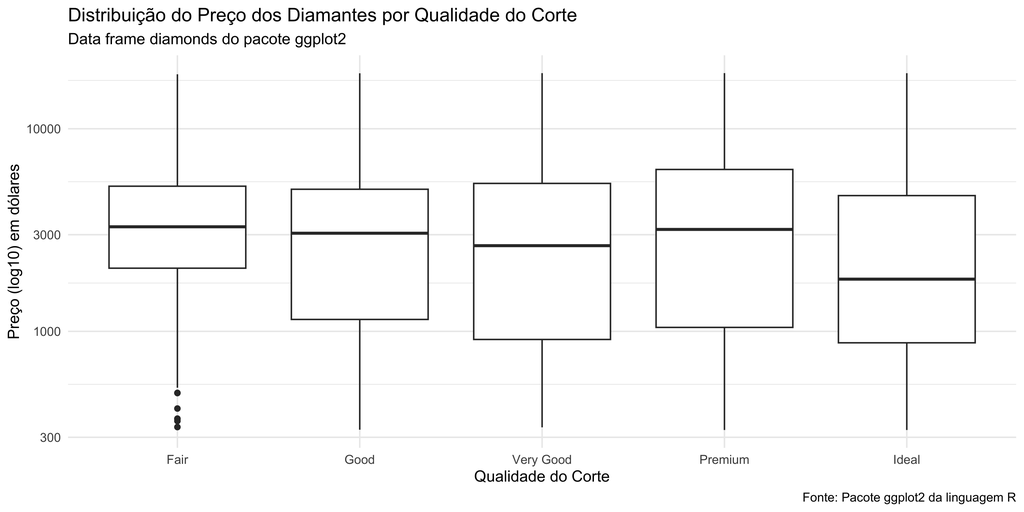

## Exercício

**Prática com ggplot2 usando a data frame `diamonds`**

**Parte 1 - Visualizando a variável `price`**

- Histograma (use a regra de Sturges para número de classes)
- Gráfico de densidade empírica
- Histograma + densidade sobreposta
- Boxplot

**Parte 2 - Análise comparativa**

- Crie boxplots de `price` por `clarity`
- Aplique transformação log10 para melhor visualização
- Compare os padrões entre as categorias

**Parte 3 - Análise descritiva**

- Analise o histograma + densidade da Parte 1
- Siga as diretrizes apresentadas em aula
- Comente sobre forma, centro, dispersão e outliers

**Requisitos:**

- Todos os gráficos devem ter títulos e rótulos apropriados
- Customização visual é opcional (exploratório vs. publicação)

**Dica:** A distribuição de `price` é assimétrica. Experimente visualizar também `log10(price)` para comparar interpretações nas duas escalas.

# Gráfico com Qualidade de Publicação

[figure not shown]

## Anatomia de uma Visualização Profissional

**Elementos de Excelência no Gráfico de Gilbert Fontana**

**1. Hierarquia da Informação**

- Título claro e direto
- Subtítulo contextualizando a métrica
- Dados organizados em pequenos múltiplos

**2. Design Minimalista e Funcional**

- Fundo neutro (#F4F5F1) que não compete com os dados
- Espaçamento generoso entre elementos
- Ausência de bordas e gridlines desnecessárias

**3. Uso Estratégico de Cores**

- Paleta artística coerente (MetBrewer::Redon)
- Destaque automático com outras séries em cinza
- Cores distintas mas harmoniosas para cada país

**4. Anotações e Contexto**

- Valores finais destacados ao lado de cada série
- Linha de referência em 100 (baseline significativa)
- Explicação clara do indicador no subtítulo

**5. Detalhes Técnicos Refinados**

- Tipografia consistente (Google Font: Gudea)
- Eixos simplificados (anos em formato ’20, ’21, ’22)
- Créditos apropriados (designer e fonte dos dados)
- Código reproduzível e bem documentado

## Atualizando os Repositórios

**Instruções**

1. No terminal do RStudio, verifique quais arquivos/pastas foram modificados ou criados com:

```bash
git status
```

2. Você pode adicionar todos os arquivos de uma vez com:

```bash
git add .
```

3. Execute git status novamente para confirmar que todos os arquivos foram adicionados (aparecerão em verde sob “*Changes to be committed*”):

```bash
git status
```

4. Se tudo estiver em verde, faça um commit com uma mensagem descritiva:

```bash
git commit -m "atualizacoes aula 20"
```

5. Se algum arquivo ou pasta ainda aparecer em vermelho após o segundo git status, adicione as pastas/arquivos um por um:

```bash
git add relatorios/12-relatorio/12-relatorio.qmd
```

6. Execute git status novamente e faça o commit quando todos os arquivos estiverem em verde:

```bash
git commit -m "atualizacoes aula 20"
```

7. Envie o repositório local atualizado para o GitHub:

```bash
git push origin main
```